# Part I - (Loan Data from Prosper)

## Preliminary Wrangling

```python
# import all packages and set plots to be embedded inline
# Import needed Python Libraries
import pandas as pd
import numpy as np
import seaborn as sns
import matplotlib.pyplot as plt

%matplotlib inline

#import warnings
import warnings
warnings.filterwarnings('ignore')

%matplotlib inline
```

> Load in your dataset and describe its properties through the questions below. Try and motivate your exploration goals through this section.

```python
df = pd.read_csv('prosperLoanData.csv')
df
```

|  | ListingKey | ListingNumber | ListingCreationDate | CreditGrade | Term | LoanStatus | ClosedDate | BorrowerAPR | BorrowerRate | LenderYield | ... | LP_ServiceFees | LP_CollectionFees | LP_GrossPrincipalLoss | LP_NetPrincipalLoss | LP_NonPrincipalRecoverypayments | PercentFunded | Recommendations | InvestmentFromFriendsCount | InvestmentFromFriendsAmount | Investors |
| --- | --- | --- | --- | --- | --- | --- | --- | --- | --- | --- | --- | --- | --- | --- | --- | --- | --- | --- | --- | --- | --- |
| 0 | 1021339766868145413AB3B | 193129 | 2007-08-26 19:09:29.263000000 | C | 36 | Completed | 2009-08-14 00:00:00 | 0.16516 | 0.1580 | 0.1380 | ... | -133.18 | 0.0 | 0.0 | 0.0 | 0.0 | 1.0 | 0 | 0 | 0.0 | 258 |
| 1 | 10273602499503308B223C1 | 1209647 | 2014-02-27 08:28:07.900000000 | NaN | 36 | Current | NaN | 0.12016 | 0.0920 | 0.0820 | ... | 0.00 | 0.0 | 0.0 | 0.0 | 0.0 | 1.0 | 0 | 0 | 0.0 | 1 |
| 2 | 0EE9337825851032864889A | 81716 | 2007-01-05 15:00:47.090000000 | HR | 36 | Completed | 2009-12-17 00:00:00 | 0.28269 | 0.2750 | 0.2400 | ... | -24.20 | 0.0 | 0.0 | 0.0 | 0.0 | 1.0 | 0 | 0 | 0.0 | 41 |
| 3 | 0EF5356002482715299901A | 658116 | 2012-10-22 11:02:35.010000000 | NaN | 36 | Current | NaN | 0.12528 | 0.0974 | 0.0874 | ... | -108.01 | 0.0 | 0.0 | 0.0 | 0.0 | 1.0 | 0 | 0 | 0.0 | 158 |
| 4 | 0F023589499656230C5E3E2 | 909464 | 2013-09-14 18:38:39.097000000 | NaN | 36 | Current | NaN | 0.24614 | 0.2085 | 0.1985 | ... | -60.27 | 0.0 | 0.0 | 0.0 | 0.0 | 1.0 | 0 | 0 | 0.0 | 20 |
| ... | ... | ... | ... | ... | ... | ... | ... | ... | ... | ... | ... | ... | ... | ... | ... | ... | ... | ... | ... | ... | ... |
| 113932 | E6D9357655724827169606C | 753087 | 2013-04-14 05:55:02.663000000 | NaN | 36 | Current | NaN | 0.22354 | 0.1864 | 0.1764 | ... | -75.58 | 0.0 | 0.0 | 0.0 | 0.0 | 1.0 | 0 | 0 | 0.0 | 1 |
| 113933 | E6DB353036033497292EE43 | 537216 | 2011-11-03 20:42:55.333000000 | NaN | 36 | FinalPaymentInProgress | NaN | 0.13220 | 0.1110 | 0.1010 | ... | -30.05 | 0.0 | 0.0 | 0.0 | 0.0 | 1.0 | 0 | 0 | 0.0 | 22 |
| 113934 | E6E13596170052029692BB1 | 1069178 | 2013-12-13 05:49:12.703000000 | NaN | 60 | Current | NaN | 0.23984 | 0.2150 | 0.2050 | ... | -16.91 | 0.0 | 0.0 | 0.0 | 0.0 | 1.0 | 0 | 0 | 0.0 | 119 |
| 113935 | E6EB3531504622671970D9E | 539056 | 2011-11-14 13:18:26.597000000 | NaN | 60 | Completed | 2013-08-13 00:00:00 | 0.28408 | 0.2605 | 0.2505 | ... | -235.05 | 0.0 | 0.0 | 0.0 | 0.0 | 1.0 | 0 | 0 | 0.0 | 274 |
| 113936 | E6ED3600409833199F711B7 | 1140093 | 2014-01-15 09:27:37.657000000 | NaN | 36 | Current | NaN | 0.13189 | 0.1039 | 0.0939 | ... | -1.70 | 0.0 | 0.0 | 0.0 | 0.0 | 1.0 | 0 | 0 | 0.0 | 1 |

113937 rows × 81 columns

```python
df.info()
```

```
<class 'pandas.core.frame.DataFrame'>
RangeIndex: 113937 entries, 0 to 113936
Data columns (total 81 columns):
 #   Column                               Non-Null Count   Dtype
---  ------                               --------------   -----
 0   ListingKey                           113937 non-null  object
 1   ListingNumber                        113937 non-null  int64
 2   ListingCreationDate                  113937 non-null  object
 3   CreditGrade                          28953 non-null   object
 4   Term                                 113937 non-null  int64
 5   LoanStatus                           113937 non-null  object
 6   ClosedDate                           55089 non-null   object
 7   BorrowerAPR                          113912 non-null  float64
 8   BorrowerRate                         113937 non-null  float64
 9   LenderYield                          113937 non-null  float64
```

[output cut: 73 more lines]

### Clean data

```python
# Define the subset of columns you're interested in
selected_columns = [
    'LoanStatus', 'BorrowerAPR', 'EmploymentStatus', 'StatedMonthlyIncome',
    'IncomeVerifiable', 'DebtToIncomeRatio', 'LoanOriginalAmount', 'Term',
    'ProsperRating (Alpha)', 'ProsperRating (numeric)', 'CreditGrade',
    'BorrowerRate', 'EstimatedEffectiveYield', 'EstimatedLoss', 'EstimatedReturn'
]

# Create a new DataFrame with only the selected columns
loan_subset = df[selected_columns]
```

```python
loan_subset.columns
```

```
Index(['LoanStatus', 'BorrowerAPR', 'EmploymentStatus', 'StatedMonthlyIncome',
       'IncomeVerifiable', 'DebtToIncomeRatio', 'LoanOriginalAmount', 'Term',
       'ProsperRating (Alpha)', 'ProsperRating (numeric)', 'CreditGrade',
       'BorrowerRate', 'EstimatedEffectiveYield', 'EstimatedLoss',
       'EstimatedReturn'],
      dtype='object')
```

```python
loan_subset.describe(include='all')
```

|  | LoanStatus | BorrowerAPR | EmploymentStatus | StatedMonthlyIncome | IncomeVerifiable | DebtToIncomeRatio | LoanOriginalAmount | Term | ProsperRating (Alpha) | ProsperRating (numeric) | CreditGrade | BorrowerRate | EstimatedEffectiveYield | EstimatedLoss | EstimatedReturn |
| --- | --- | --- | --- | --- | --- | --- | --- | --- | --- | --- | --- | --- | --- | --- | --- |
| count | 113937 | 113912.000000 | 111682 | 1.139370e+05 | 113937 | 105383.000000 | 113937.00000 | 113937.000000 | 84853 | 84853.000000 | 28953 | 113937.000000 | 84853.000000 | 84853.000000 | 84853.000000 |
| unique | 12 | NaN | 8 | NaN | 2 | NaN | NaN | NaN | 7 | NaN | 8 | NaN | NaN | NaN | NaN |
| top | Current | NaN | Employed | NaN | True | NaN | NaN | NaN | C | NaN | C | NaN | NaN | NaN | NaN |
| freq | 56576 | NaN | 67322 | NaN | 105268 | NaN | NaN | NaN | 18345 | NaN | 5649 | NaN | NaN | NaN | NaN |
| mean | NaN | 0.218828 | NaN | 5.608026e+03 | NaN | 0.275947 | 8337.01385 | 40.830248 | NaN | 4.072243 | NaN | 0.192764 | 0.168661 | 0.080306 | 0.096068 |
| std | NaN | 0.080364 | NaN | 7.478497e+03 | NaN | 0.551759 | 6245.80058 | 10.436212 | NaN | 1.673227 | NaN | 0.074818 | 0.068467 | 0.046764 | 0.030403 |
| min | NaN | 0.006530 | NaN | 0.000000e+00 | NaN | 0.000000 | 1000.00000 | 12.000000 | NaN | 1.000000 | NaN | 0.000000 | -0.182700 | 0.004900 | -0.182700 |
| 25% | NaN | 0.156290 | NaN | 3.200333e+03 | NaN | 0.140000 | 4000.00000 | 36.000000 | NaN | 3.000000 | NaN | 0.134000 | 0.115670 | 0.042400 | 0.074080 |
| 50% | NaN | 0.209760 | NaN | 4.666667e+03 | NaN | 0.220000 | 6500.00000 | 36.000000 | NaN | 4.000000 | NaN | 0.184000 | 0.161500 | 0.072400 | 0.091700 |
| 75% | NaN | 0.283810 | NaN | 6.825000e+03 | NaN | 0.320000 | 12000.00000 | 36.000000 | NaN | 5.000000 | NaN | 0.250000 | 0.224300 | 0.112000 | 0.116600 |
| max | NaN | 0.512290 | NaN | 1.750003e+06 | NaN | 10.010000 | 35000.00000 | 60.000000 | NaN | 7.000000 | NaN | 0.497500 | 0.319900 | 0.366000 | 0.283700 |

```python
loan_subset.info()
```

```
<class 'pandas.core.frame.DataFrame'>
RangeIndex: 113937 entries, 0 to 113936
Data columns (total 15 columns):
 #   Column                   Non-Null Count   Dtype
---  ------                   --------------   -----
 0   LoanStatus               113937 non-null  object
 1   BorrowerAPR              113912 non-null  float64
 2   EmploymentStatus         111682 non-null  object
 3   StatedMonthlyIncome      113937 non-null  float64
 4   IncomeVerifiable         113937 non-null  bool
 5   DebtToIncomeRatio        105383 non-null  float64
 6   LoanOriginalAmount       113937 non-null  int64
 7   Term                     113937 non-null  int64
 8   ProsperRating (Alpha)    84853 non-null   object
 9   ProsperRating (numeric)  84853 non-null   float64
 10  CreditGrade              28953 non-null   object
 11  BorrowerRate             113937 non-null  float64
 12  EstimatedEffectiveYield  84853 non-null   float64
 13  EstimatedLoss            84853 non-null   float64
 14  EstimatedReturn          84853 non-null   float64
dtypes: bool(1), float64(8), int64(2), object(4)
memory usage: 12.3+ MB
```

```python
loan_subset.shape
```

```
(113937, 15)
```

### What is the structure of your dataset?

> This data set contains 113,937 loans with 81 variables on each loan, including loan amount, borrower rate (or interest rate), current loan status, borrower income, and many others.

### What is/are the main feature(s) of interest in your dataset?

> What affects the borrower's APR "Annual Percentage Rate"?

### What features in the dataset do you think will help support your investigation into your feature(s) of interest?

> Each of the features in your dataset can influence the APR (Annual Percentage Rate) in different ways. Here's how they might impact the APR:

```
ProsperRating (numeric) / ProsperRating (Alpha):
    Impact: These ratings represent the creditworthiness of the borrower. A higher rating (better creditworthiness) typically leads to a lower APR because the borrower is considered less risky. Conversely, a lower rating suggests higher risk, which usually results in a higher APR to compensate for that risk.

CreditGrade:
    Impact: Similar to the ProsperRating, the credit grade reflects the borrower's credit history. Higher credit grades (e.g., A, B) usually result in lower APRs, while lower grades (e.g., D, E) can lead to higher APRs.
Term:
    Impact: The loan term refers to the duration over which the loan is to be repaid. Longer terms may come with higher APRs because they pose a greater risk to the lender over time. Conversely, shorter terms might have lower APRs.
EmploymentStatus:
    Impact: A stable employment status suggests a steady income, which can lead to a lower APR since the borrower is viewed as less risky. Unemployment or unstable employment may result in higher APRs.
BorrowerRate:
    Impact: The BorrowerRate is closely related to the BorrowerAPR. A higher BorrowerRate usually indicates a higher APR, as both represent the cost of the loan to the borrower. The APR includes additional costs beyond just the interest rate.
EstimatedEffectiveYield:
    Impact: This is an estimate of the yield the lender might expect after accounting for losses. If the estimated yield is low, the APR might be higher to ensure the lender's return remains attractive.
EstimatedLoss:
    Impact: This estimates the potential loss the lender might face. Higher estimated losses typically lead to higher APRs to compensate for the increased risk.
EstimatedReturn:
    Impact: This is the return expected after accounting for losses. A lower estimated return might necessitate a higher APR to make the loan worthwhile for the lender.
```

These features help lenders assess the risk associated with a borrower and determine the appropriate APR to charge, balancing the potential return with the risk of lending.

## Univariate Exploration

> In this section, investigate distributions of individual variables. If you see unusual points or outliers, take a deeper look to clean things up and prepare yourself to look at relationships between variables.

> **Rubric Tip**: The project (Parts I alone) should have at least 15 visualizations distributed over univariate, bivariate, and multivariate plots to explore many relationships in the data set. Use reasoning to justify the flow of the exploration.

> **Rubric Tip**: Use the "Question-Visualization-Observations" framework throughout the exploration. This framework involves **asking a question from the data, creating a visualization to find answers, and then recording observations after each visualisation.**

```python
import matplotlib.pyplot as plt
# Define dynamic set chart labels
def set_chart_labels(x_label, y_label, title):
    plt.title(title)
    plt.xlabel(x_label)
    plt.ylabel(y_label)
```

```python
loan_subset.info()
```

```
<class 'pandas.core.frame.DataFrame'>
RangeIndex: 113937 entries, 0 to 113936
Data columns (total 15 columns):
 #   Column                   Non-Null Count   Dtype
---  ------                   --------------   -----
 0   LoanStatus               113937 non-null  object
 1   BorrowerAPR              113912 non-null  float64
 2   EmploymentStatus         111682 non-null  object
 3   StatedMonthlyIncome      113937 non-null  float64
 4   IncomeVerifiable         113937 non-null  bool
 5   DebtToIncomeRatio        105383 non-null  float64
 6   LoanOriginalAmount       113937 non-null  int64
 7   Term                     113937 non-null  int64
 8   ProsperRating (Alpha)    84853 non-null   object
 9   ProsperRating (numeric)  84853 non-null   float64
 10  CreditGrade              28953 non-null   object
 11  BorrowerRate             113937 non-null  float64
 12  EstimatedEffectiveYield  84853 non-null   float64
 13  EstimatedLoss            84853 non-null   float64
 14  EstimatedReturn          84853 non-null   float64
dtypes: bool(1), float64(8), int64(2), object(4)
memory usage: 12.3+ MB
```

> **Rubric Tip**: Visualizations should depict the data appropriately so that the plots are easily interpretable. You should choose an appropriate plot type, data encodings, and formatting as needed. The formatting may include setting/adding the title, labels, legend, and comments. Also, do not overplot or incorrectly plot ordinal data.

### What was the loan status for the borrowers?

```python
loan_subset
```

|  | LoanStatus | BorrowerAPR | EmploymentStatus | StatedMonthlyIncome | IncomeVerifiable | DebtToIncomeRatio | LoanOriginalAmount | Term | ProsperRating (Alpha) | ProsperRating (numeric) | CreditGrade | BorrowerRate | EstimatedEffectiveYield | EstimatedLoss | EstimatedReturn |
| --- | --- | --- | --- | --- | --- | --- | --- | --- | --- | --- | --- | --- | --- | --- | --- |
| 0 | Completed | 0.16516 | Self-employed | 3083.333333 | True | 0.17 | 9425 | 36 | NaN | NaN | C | 0.1580 | NaN | NaN | NaN |
| 1 | Current | 0.12016 | Employed | 6125.000000 | True | 0.18 | 10000 | 36 | A | 6.0 | NaN | 0.0920 | 0.07960 | 0.0249 | 0.05470 |
| 2 | Completed | 0.28269 | Not available | 2083.333333 | True | 0.06 | 3001 | 36 | NaN | NaN | HR | 0.2750 | NaN | NaN | NaN |
| 3 | Current | 0.12528 | Employed | 2875.000000 | True | 0.15 | 10000 | 36 | A | 6.0 | NaN | 0.0974 | 0.08490 | 0.0249 | 0.06000 |
| 4 | Current | 0.24614 | Employed | 9583.333333 | True | 0.26 | 15000 | 36 | D | 3.0 | NaN | 0.2085 | 0.18316 | 0.0925 | 0.09066 |
| ... | ... | ... | ... | ... | ... | ... | ... | ... | ... | ... | ... | ... | ... | ... | ... |
| 113932 | Current | 0.22354 | Employed | 4333.333333 | True | 0.13 | 10000 | 36 | C | 4.0 | NaN | 0.1864 | 0.16490 | 0.0699 | 0.09500 |
| 113933 | FinalPaymentInProgress | 0.13220 | Employed | 8041.666667 | True | 0.11 | 2000 | 36 | A | 6.0 | NaN | 0.1110 | 0.10070 | 0.0200 | 0.08070 |
| 113934 | Current | 0.23984 | Employed | 2875.000000 | True | 0.51 | 10000 | 60 | D | 3.0 | NaN | 0.2150 | 0.18828 | 0.1025 | 0.08578 |
| 113935 | Completed | 0.28408 | Full-time | 3875.000000 | True | 0.48 | 15000 | 60 | C | 4.0 | NaN | 0.2605 | 0.24450 | 0.0850 | 0.15950 |
| 113936 | Current | 0.13189 | Employed | 4583.333333 | True | 0.23 | 2000 | 36 | A | 6.0 | NaN | 0.1039 | 0.09071 | 0.0299 | 0.06081 |

113937 rows × 15 columns

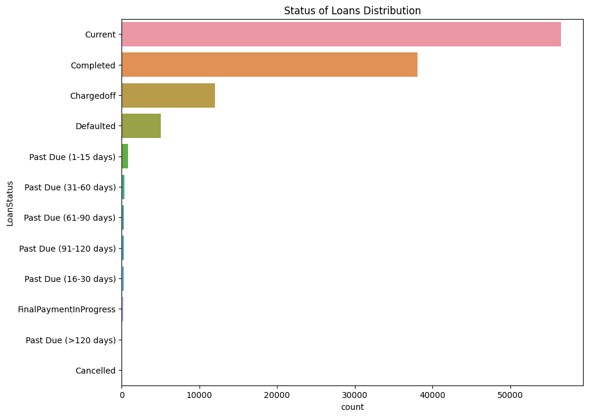

```python
import matplotlib.pyplot as plt
import seaborn as sns

# Define the color for the plot (if needed)
# Use a named color or hex code if `bcolor` causes issues
# bcolor = sns.color_palette()[0]

# Ensure `cate_order` is properly defined
cate_order = loan_subset['LoanStatus'].value_counts().index

# Create the plot
plt.figure(figsize=[10, 8])
sns.countplot(data=loan_subset, y='LoanStatus', order=cate_order)

# Set the plot title
plt.title('Status of Loans Distribution')

# Show the plot
plt.show()
```

### BorrowerAPR

What is the overall distribution of APR values among borrowers?

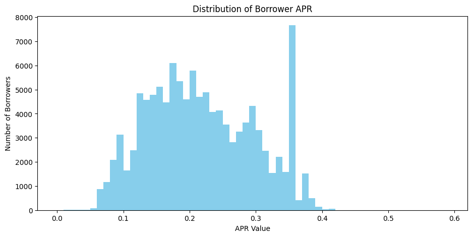

```python
import matplotlib.pyplot as plt
import numpy as np

# Set the figure size
from matplotlib import rcParams
rcParams['figure.figsize'] = 11, 5

# Define bins for the histogram
bins = np.arange(0, loan_subset['BorrowerAPR'].max() + 0.08, 0.01)

# Plot the histogram with color
plt.hist(loan_subset['BorrowerAPR'], bins=bins, color='skyblue')  # Change 'skyblue' to your desired color

# Set the plot labels and title
plt.xlabel('APR Value')  # Update with your desired x-axis label
plt.ylabel('Number of Borrowers')  # Update with your desired y-axis label
plt.title('Distribution of Borrower APR')

# Turn off the grid
plt.grid(False)

# Show the plot
plt.show()
```

The histogram of BorrowerAPR reveals a multimodal distribution with several notable features:

Multimodal Peaks: The distribution exhibits small peaks at APR values of 0.1 and a larger peak at 0.2, suggesting that these APR ranges are more common among borrowers. Downward Trend: Following the peak at 0.2, there is a general downward trend in the number of borrowers, with another noticeable peak around 0.3. Sudden Spike: There is a sudden spike at 0.35, indicating a concentration of APR values in this range. Limited Higher Values: The frequency of loans with APR values above 0.42 is minimal, indicating that very high APRs are relatively rare in this dataset. This distribution provides valuable insights into the common APR ranges for borrowers and highlights areas where further analysis may be needed to understand the factors influencing APR variability.

### EmploymentStatus

How is the employment status distributed among borrowers who applied for loans?

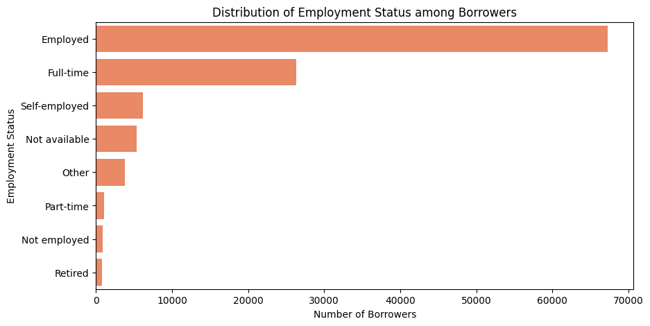

```python
import matplotlib.pyplot as plt
import seaborn as sns

# Set the figure size
plt.figure(figsize=[10, 5])

# Define a different color for the plot
color = 'coral'  # Replace 'coral' with your desired color

# Create the count plot
sns.countplot(data=loan_subset, y='EmploymentStatus', color=color,
              order=loan_subset['EmploymentStatus'].value_counts().index)

# Set the plot labels and title
plt.xlabel('Number of Borrowers')  # Update with your desired x-axis label
plt.ylabel('Employment Status')    # Update with your desired y-axis label
plt.title('Distribution of Employment Status among Borrowers')

# Show the plot
plt.show()
```

The chart illustrates the distribution of employment statuses among borrowers who were approved for loans. It shows that the majority of borrowers are categorized as 'Employed,' with 'Full-Time' being the next most common employment status. This suggests that most approved borrowers have stable employment. In contrast, 'Not Employed' and 'Retired' categories represent a smaller segment of the approved loans. Additionally, there is a notable portion of data labeled as 'Not Available,' which indicates missing information about some borrowers' employment statuses. This missing data should be considered when interpreting the results.

### StatedMonthlyIncome

What is the distribution of stated monthly income among borrowers based on the density plot?

```python
loan_subset['StatedMonthlyIncome'].describe()
```

```
count    1.139370e+05
mean     5.608026e+03
std      7.478497e+03
min      0.000000e+00
25%      3.200333e+03
50%      4.666667e+03
75%      6.825000e+03
max      1.750003e+06
Name: StatedMonthlyIncome, dtype: float64
```

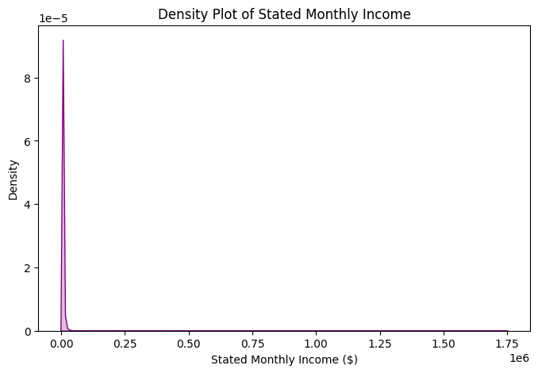

```python
import seaborn as sns
import matplotlib.pyplot as plt

# Set the figure size
plt.figure(figsize=[8, 5])

# Create the density plot
sns.kdeplot(data=loan_subset, x='StatedMonthlyIncome', fill=True, color='purple')

# Set the plot labels and title
plt.xlabel('Stated Monthly Income ($)')
plt.ylabel('Density')
plt.title('Density Plot of Stated Monthly Income')

# Show the plot
plt.show()
```

From the chart, we can observe that the distribution of stated monthly income is right-skewed. This indicates that while most borrowers report lower incomes, there is a smaller number of borrowers with higher incomes. Specifically, a significant proportion of loans have stated monthly incomes below $30,000, suggesting that the majority of borrowers fall within this lower income bracket. The right skewness highlights that higher income ranges are less common but present in the dataset.

### IncomeVerifiable

What proportion of borrowers have verifiable versus unverifiable income according to the chart?

```python
loan_subset['IncomeVerifiable'].describe()
```

```
count     113937
unique         2
top         True
freq      105268
Name: IncomeVerifiable, dtype: object
```

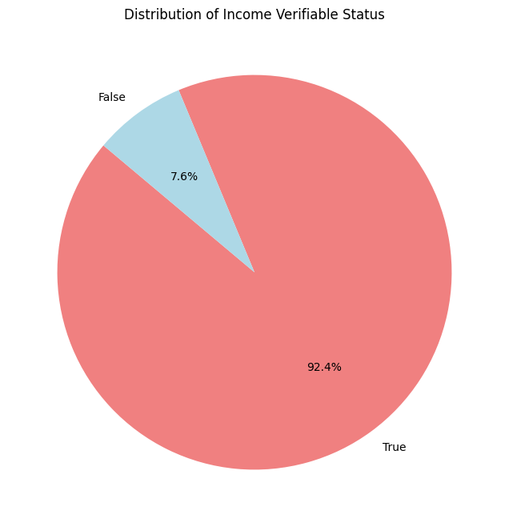

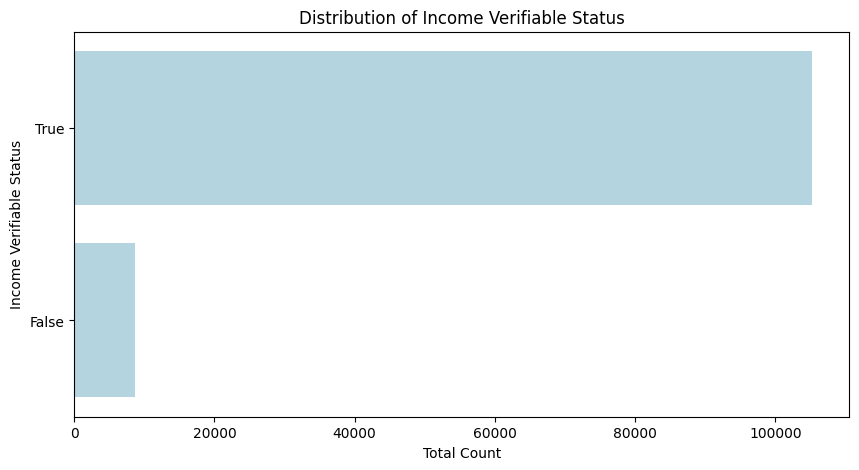

```python
import matplotlib.pyplot as plt
import seaborn as sns

# Count the occurrences of each category
income_verifiable_counts = loan_subset['IncomeVerifiable'].value_counts()

# Define the color palette
colors = ['lightcoral', 'lightblue', 'lightgreen']  # Adjust colors as needed

# Create the pie chart
plt.figure(figsize=[8, 8])
plt.pie(income_verifiable_counts, labels=income_verifiable_counts.index, colors=colors, autopct='%1.1f%%', startangle=140)

# Set the plot title
plt.title('Distribution of Income Verifiable Status')

# Show the plot
plt.show()



# Set the figure size
plt.figure(figsize=[10, 5])

# Define the color you want to use
color = 'lightblue'  # Change this to your desired color

# Create the count plot
sns.countplot(data=loan_subset, y='IncomeVerifiable', color=color, order=loan_subset['IncomeVerifiable'].value_counts().index)

# Set the plot labels and title
plt.xlabel('Total Count')
plt.ylabel('Income Verifiable Status')
plt.title('Distribution of Income Verifiable Status')

# Show the plot
plt.show()
```

### LoanOriginalAmount

What does the histogram reveal about the distribution of loan original amounts among borrowers?

```python
loan_subset['LoanOriginalAmount'].describe()
```

```
count    113937.00000
mean       8337.01385
std        6245.80058
min        1000.00000
25%        4000.00000
50%        6500.00000
75%       12000.00000
max       35000.00000
Name: LoanOriginalAmount, dtype: float64
```

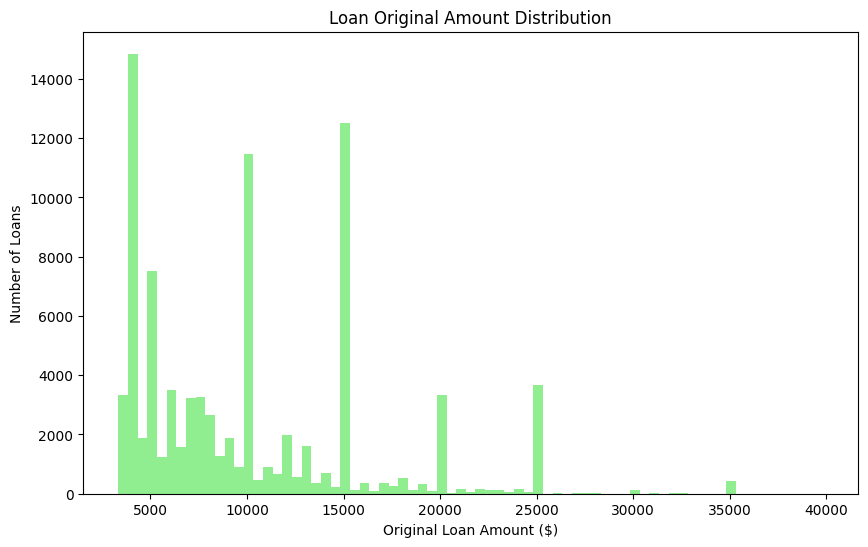

```python
import matplotlib.pyplot as plt
import numpy as np

# Calculate the mean of LoanOriginalAmount
mean_loan_amount = loan_subset['LoanOriginalAmount'].mean()

# Define bins starting from the mean
bins = np.arange(mean_loan_amount - 5000, loan_subset['LoanOriginalAmount'].max() + 5000, 500)

# Plot the histogram with a new color
plt.figure(figsize=[10, 6])
plt.hist(loan_subset['LoanOriginalAmount'], bins=bins, color='lightgreen')  # Change to your preferred color

# Set the plot labels and title
plt.xlabel('Original Loan Amount ($)')
plt.ylabel('Number of Loans')
plt.title('Loan Original Amount Distribution')

# Turn off the grid
plt.grid(False)

# Show the plot
plt.show()
```

### Term

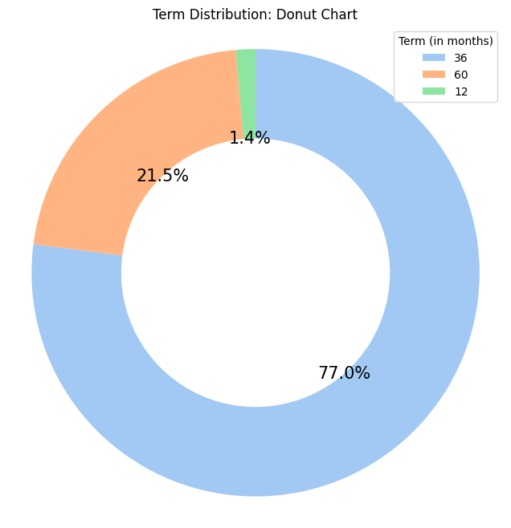

```python
import matplotlib.pyplot as plt
import seaborn as sns
import pandas as pd

# Prepare the data
sorted_term = pd.DataFrame(loan_subset['Term'].value_counts().reset_index())
sorted_term.columns = ['Term', 'Count']  # Rename columns for clarity
labels = sorted_term['Term']
textprops = {"fontsize":15}

# Define a color palette from Seaborn
colors = sns.color_palette("pastel", n_colors=len(sorted_term))

# Plot the donut chart with the Seaborn color palette
plt.figure(figsize=[8, 8])
plt.pie(sorted_term['Count'], labels=None, startangle=90, counterclock=False,
        wedgeprops={'width': 0.4}, autopct='%.1f%%', textprops=textprops, colors=colors)

# Add legend and title
plt.axis('square')
plt.title('Term Distribution: Donut Chart')
plt.legend(labels, title='Term (in months)')

# Show the plot
plt.show()
```

### ProsperRating (Alpha)

```python
loan_subset['ProsperRating (Alpha)'].describe()
```

```
count     84853
unique        7
top           C
freq      18345
Name: ProsperRating (Alpha), dtype: object
```

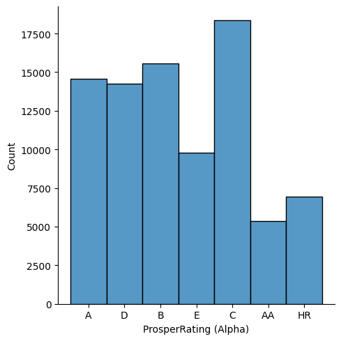

```python
sns.displot(loan_subset, x='ProsperRating (Alpha)')
```

## Bivariate Exploration

> In this section, investigate relationships between pairs of variables in your data. Make sure the variables that you cover here have been introduced in some fashion in the previous section (univariate exploration).

What is the relationship between Employment Status and Loan Amount Given?

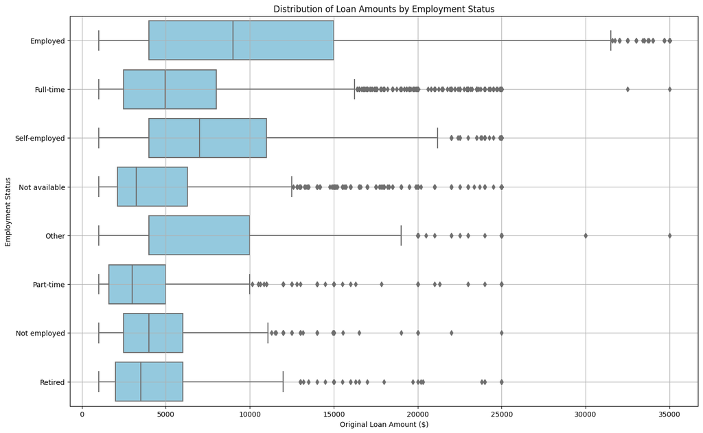

```python
cate_order = loan_subset.EmploymentStatus.value_counts().index

plt.figure(figsize = [16, 10])
box_color = 'skyblue'

sns.boxplot(data=loan_subset, x='LoanOriginalAmount', y='EmploymentStatus', color=box_color, order=cate_order)
plt.title('Distribution of Loan Amounts by Employment Status')
plt.xlabel('Original Loan Amount ($)')
plt.ylabel('Employment Status')
plt.grid(True)
```

Being employed provides borrowers with a greater opportunity to access larger loans, as stable employment is often viewed positively by lenders and is associated with a higher likelihood of loan approval.

### Numeric Variables Observation

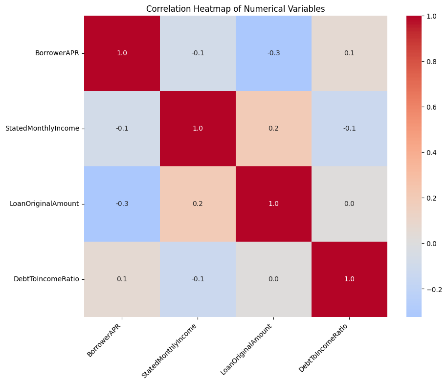

```python
import seaborn as sns
import matplotlib.pyplot as plt

# Define numerical variables for correlation matrix
num_var = ['BorrowerAPR', 'StatedMonthlyIncome', 'LoanOriginalAmount', 'DebtToIncomeRatio']

# Create the heatmap
plt.figure(figsize=[10, 8])
sns.heatmap(
    loan_subset[num_var].corr(),
    annot=True,                    # Display correlation coefficients
    fmt='.1f',                     # Format numbers to 1 decimal place
    cmap='coolwarm',               # Change color map
    center=0                       # Center the color map at 0
)

# Set plot labels and title
plt.title('Correlation Heatmap of Numerical Variables')
plt.xticks(rotation=45, ha='right')  # Rotate x-axis labels for better readability
plt.yticks(rotation=0)               # Ensure y-axis labels are horizontal

# Show the plot
plt.show()
```

Negative Correlation Between Borrower APR and Loan Amount: This suggests that larger loans tend to come with lower APRs, which might be a reflection of lenders offering better terms for larger amounts.

Negative Correlation Between Debt-to-Income Ratio and Stated Monthly Income: This indicates that as a borrower’s stated income increases, their debt-to-income ratio decreases, suggesting improved financial health.

Positive Correlation Between Loan Amount and Stated Monthly Income: Higher incomes generally lead to the ability to take on larger loans, which aligns with expectations of financial stability and borrowing capacity.

This analysis helps in understanding how different financial metrics are interrelated and can be crucial for decision-making in lending and financial planning.

## Multivariate Exploration

> Create plots of three or more variables to investigate your data even further. Make sure that your investigations are justified, and follow from your work in the previous sections.

### relationship between each categorical variables

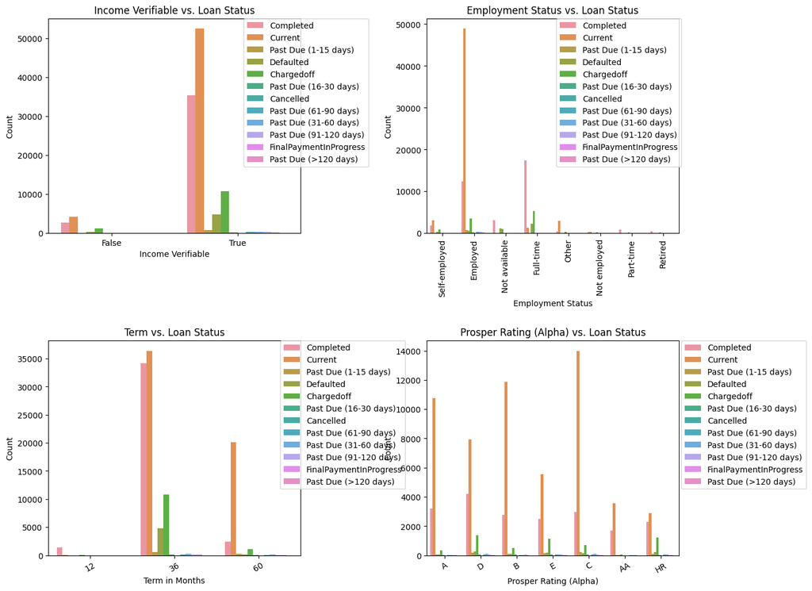

```python
import matplotlib.pyplot as plt
import seaborn as sb
from matplotlib import rcParams

# Set figure size
rcParams['figure.figsize'] = 14, 12

# Create the figure and subplots
fig, axs = plt.subplots(2, 2)

# Subplot 1: Income Verifiable vs. Loan Status
sb.countplot(data=loan_subset, x='IncomeVerifiable', hue='LoanStatus', ax=axs[0, 0])
axs[0, 0].legend(bbox_to_anchor=(1.27, 1), borderaxespad=0)  # Push the legend to the side
axs[0, 0].set_title('Income Verifiable vs. Loan Status')
axs[0, 0].set_xlabel('Income Verifiable')
axs[0, 0].set_ylabel('Count')

# Subplot 2: Employment Status vs. Loan Status
sb.countplot(data=loan_subset, x='EmploymentStatus', hue='LoanStatus', ax=axs[0, 1])
axs[0, 1].legend(bbox_to_anchor=(1.01, 1), borderaxespad=0)  # Push the legend to the side
axs[0, 1].set_title('Employment Status vs. Loan Status')
axs[0, 1].set_xlabel('Employment Status')
axs[0, 1].set_ylabel('Count')
axs[0, 1].tick_params(axis='x', rotation=90)  # Rotate x labels for better readability

# Subplot 3: Term vs. Loan Status
sb.countplot(data=loan_subset, x='Term', hue='LoanStatus', ax=axs[1, 0])
axs[1, 0].legend(bbox_to_anchor=(0.92, 1), borderaxespad=0)  # Push the legend to the side
axs[1, 0].set_title('Term vs. Loan Status')
axs[1, 0].set_xlabel('Term in Months')
axs[1, 0].set_ylabel('Count')
axs[1, 0].tick_params(axis='x', rotation=30)  # Rotate x labels for better readability

# Subplot 4: Prosper Rating (Alpha) vs. Loan Status
sb.countplot(data=loan_subset, x='ProsperRating (Alpha)', hue='LoanStatus', ax=axs[1, 1])
axs[1, 1].legend(bbox_to_anchor=(1.01, 1), borderaxespad=0)  # Push the legend to the side
axs[1, 1].set_title('Prosper Rating (Alpha) vs. Loan Status')
axs[1, 1].set_xlabel('Prosper Rating (Alpha)')
axs[1, 1].set_ylabel('Count')
axs[1, 1].tick_params(axis='x', rotation=30)  # Rotate x labels for better readability

# Adjust layout to avoid overlap
plt.subplots_adjust(wspace=0.50, hspace=0.5)

# Show the plot
plt.show()
```

How does the duration of a loan term influence the APR across various Prosper Ratings? Do different credit ratings show distinct patterns in APR based on the length of the loan term?

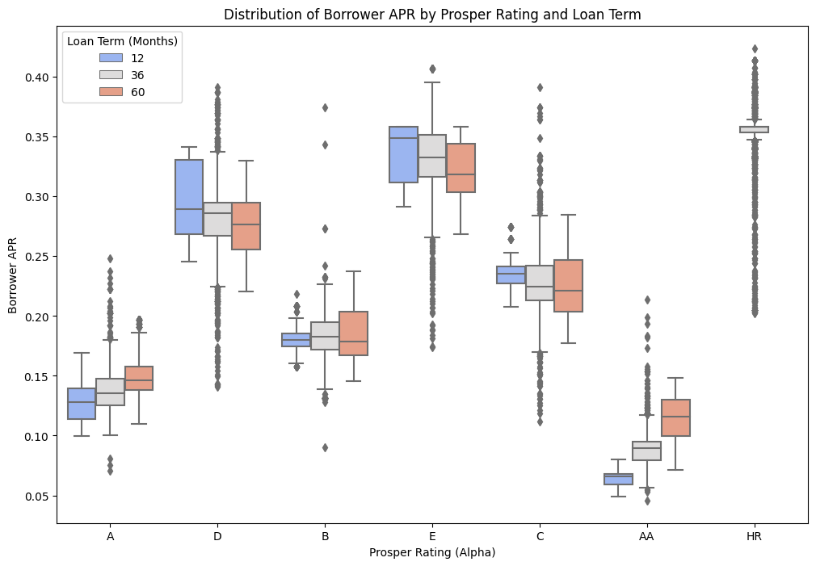

```python
import seaborn as sb
import matplotlib.pyplot as plt

# Create the figure and axis
fig = plt.figure(figsize=[12, 8])

# Create the boxplot
ax = sb.boxplot(
    x='ProsperRating (Alpha)',
    y='BorrowerAPR',
    hue='Term',
    data=loan_subset,
    palette='coolwarm'  # Change color palette
)

# Set plot title and labels
plt.title('Distribution of Borrower APR by Prosper Rating and Loan Term')
plt.xlabel('Prosper Rating (Alpha)')  # X-axis label
plt.ylabel('Borrower APR')            # Y-axis label

# Adjust legend
plt.legend(title='Loan Term (Months)')

# Show the plot
plt.show()
```

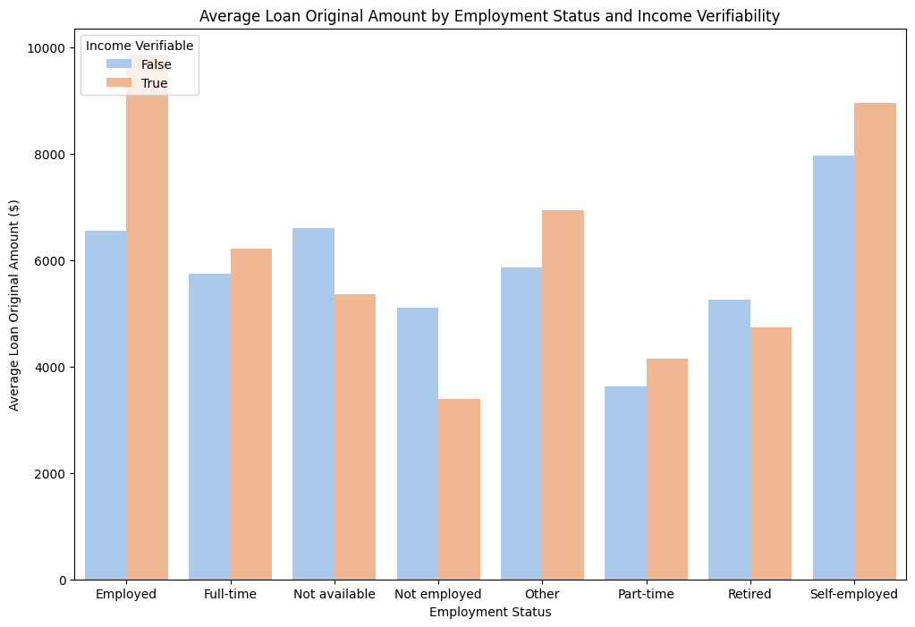

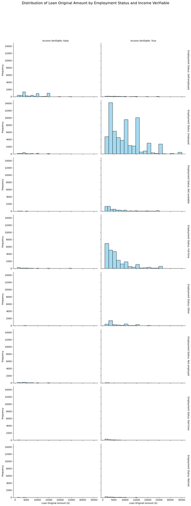

```python
import seaborn as sb
import matplotlib.pyplot as plt

# Calculate the mean LoanOriginalAmount
c_means = loan_subset.groupby(['IncomeVerifiable', 'EmploymentStatus']).mean()['LoanOriginalAmount']
c_means = c_means.reset_index(name='LoanOriginalAmount')

# Create a bar plot
plt.figure(figsize=[12, 8])
sb.barplot(data=c_means, x='EmploymentStatus', y='LoanOriginalAmount', hue='IncomeVerifiable', palette='pastel')

# Set the plot title and labels
plt.title('Average Loan Original Amount by Employment Status and Income Verifiability')
plt.xlabel('Employment Status')
plt.ylabel('Average Loan Original Amount ($)')
plt.legend(title='Income Verifiable', loc='upper left')

# --------------------------------


# Create the FacetGrid object
g = sb.FacetGrid(loan_subset, col='IncomeVerifiable', row='EmploymentStatus', margin_titles=True, aspect=1.5, height=4)

# Map the plot onto the FacetGrid
g.map_dataframe(sb.histplot, x='LoanOriginalAmount', bins=20, color='skyblue')

# Set the axis labels and title
g.set_axis_labels('Loan Original Amount ($)', 'Frequency')
g.set_titles(col_template='Income Verifiable: {col_name}', row_template='Employment Status: {row_name}')
g.fig.suptitle('Distribution of Loan Original Amount by Employment Status and Income Verifiable', fontsize=16)

# Adjust layout
g.tight_layout()
g.fig.subplots_adjust(top=0.9)

# Show the plot
plt.show()
```

## Conclusions

**2. Employment Status vs. Loan Status:

Main Finding: The majority of loans are approved for individuals categorized as 'employed' or 'full-time.' Those who are 'retired' or 'unemployed' make up a smaller portion of the loans. Reflection: Employment status is a significant factor in loan approval. The clustered bar chart helps in understanding how different employment statuses affect loan outcomes, highlighting the importance of employment stability in the lending process.

> Remove all Tips mentioned above, before you convert this notebook to PDF/HTML

> At the end of your report, make sure that you export the notebook as an html file from the `File > Download as... > HTML or PDF` menu. Make sure you keep track of where the exported file goes, so you can put it in the same folder as this notebook for project submission. Also, make sure you remove all of the quote-formatted guide notes like this one before you finish your report!